# HW12

106022113

5/12/2021

## Question 1. Deal with nonlinearity

```r
cars <- read.table("auto-data.txt",header = FALSE, na.strings = "?")
names(cars)<- c("mpg","cylinders","displacement","horsepower","weight","acceleration","model_year","origin","car_name")
cars_log <- with(cars, data.frame(log(mpg), log(cylinders), log(displacement), log(horsepower), log(weight), log(acceleration), model_year, origin))
```

### a. Run a new regression with cars_log dataset, with mpg dependent

```r
regr <- lm(log.mpg. ~ log.cylinders.+log.displacement.+log.horsepower.+log.weight.+log.acceleration.+model_year+factor(origin), data = cars_log)
summary(regr)
```

```
##
## Call:
## lm(formula = log.mpg. ~ log.cylinders. + log.displacement. +
##     log.horsepower. + log.weight. + log.acceleration. + model_year +
##     factor(origin), data = cars_log)
##
## Residuals:
##      Min       1Q   Median       3Q      Max
## -0.39727 -0.06880  0.00450  0.06356  0.38542
##
## Coefficients:
##                    Estimate Std. Error t value Pr(>|t|)
## (Intercept)        7.301938   0.361777  20.184  < 2e-16 ***
## log.cylinders.    -0.081915   0.061116  -1.340  0.18094
## log.displacement.  0.020387   0.058369   0.349  0.72707
## log.horsepower.   -0.284751   0.057945  -4.914 1.32e-06 ***
## log.weight.       -0.592955   0.085165  -6.962 1.46e-11 ***
## log.acceleration. -0.169673   0.059649  -2.845  0.00469 **
## model_year         0.030239   0.001771  17.078  < 2e-16 ***
## factor(origin)2    0.050717   0.020920   2.424  0.01580 *
## factor(origin)3    0.047215   0.020622   2.290  0.02259 *
## ---
## Signif. codes:  0 '***' 0.001 '**' 0.01 '*' 0.05 '.' 0.1 ' ' 1
##
## Residual standard error: 0.113 on 383 degrees of freedom
##   (6 observations deleted due to missingness)
## Multiple R-squared:  0.8919, Adjusted R-squared:  0.8897
## F-statistic:   395 on 8 and 383 DF,  p-value: < 2.2e-16
```

#### i. Which log-transformed factors have a significant effect on log.mpg. at 10% confidence?

**ANSWER :** According to the summary, *horsepower, weight, acceleration, model_year, and origin* have a significant effect with p-value lower than 10%.

#### ii. Do some new factors have effect on mpg, why?

**ANSWER:** Comparing to our homework last week, we can discover that *horsepower, acceleration* has become significant after taken the log of it. It can be explained that they are non-linear variables, so they won’t perform well in regression without preprocessing. After log-transforming, the results are nice.

#### iii. Which factors still have insignificant or opposite effect on mpg, why?

**ANSWER:** *Cylinders and displacement* are insignificant on mpg, it might because the distribution of cylinders is irregular and the displacement value shared a more disproportionate feature with mpg. Also, they may share high multicollinearity.

### b. Take a look at weight

#### i.Create a regression of mpg on weight from the original dataset

```r
regr_wt <- lm(mpg~weight, data = cars)
summary(regr_wt)
```

```
##
## Call:
## lm(formula = mpg ~ weight, data = cars)
##
## Residuals:
##     Min      1Q  Median      3Q     Max
## -12.012  -2.801  -0.351   2.114  16.480
##
## Coefficients:
##               Estimate Std. Error t value Pr(>|t|)
## (Intercept) 46.3173644  0.7952452   58.24   <2e-16 ***
## weight      -0.0076766  0.0002575  -29.81   <2e-16 ***
## ---
## Signif. codes:  0 '***' 0.001 '**' 0.01 '*' 0.05 '.' 0.1 ' ' 1
##
## Residual standard error: 4.345 on 396 degrees of freedom
## Multiple R-squared:  0.6918, Adjusted R-squared:  0.691
## F-statistic: 888.9 on 1 and 396 DF,  p-value: < 2.2e-16
```

#### ii . Create a regression of log.mpg. on log.weight. from cars_log

```r
regr_wt_log <- lm(log.mpg.~log.weight.,data = cars_log)
summary(regr_wt_log)
```

```
##
## Call:
## lm(formula = log.mpg. ~ log.weight., data = cars_log)
##
## Residuals:
##      Min       1Q   Median       3Q      Max
## -0.52408 -0.10441 -0.00805  0.10165  0.59384
##
## Coefficients:
##             Estimate Std. Error t value Pr(>|t|)
## (Intercept)  11.5219     0.2349   49.06   <2e-16 ***
## log.weight.  -1.0583     0.0295  -35.87   <2e-16 ***
## ---
## Signif. codes:  0 '***' 0.001 '**' 0.01 '*' 0.05 '.' 0.1 ' ' 1
##
## Residual standard error: 0.165 on 396 degrees of freedom
## Multiple R-squared:  0.7647, Adjusted R-squared:  0.7641
## F-statistic:  1287 on 1 and 396 DF,  p-value: < 2.2e-16
```

#### iii.Visualize the residuals of both regressions

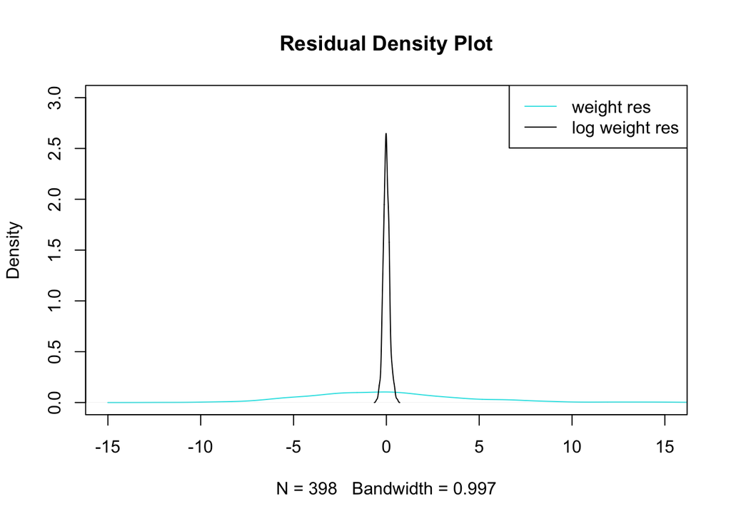

```r
plot(density(regr_wt$residuals),ylim = c(0,3),xlim = c(-15,15),col = 5,main = "Residual Density Plot")
lines(density(regr_wt_log$residuals),col = 1)
legend("topright",c("weight res", "log weight res"),lty = c(1,1),col =c(5,1))
```

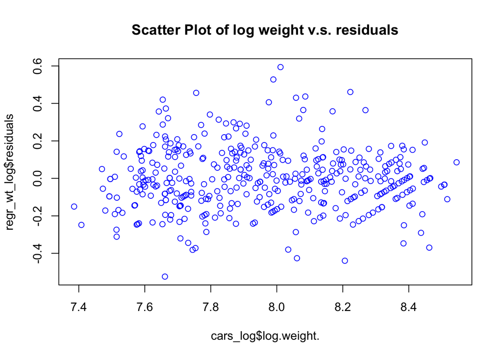

```r
plot(cars_log$log.weight.,regr_wt_log$residuals,col = 'blue', main = "Scatter Plot of log weight v.s. residuals")
```

#### iv. Which regression produces better residuals for assumptions of regression?

**ANSWER:** Observing the density plot of residuals before and after log-transformation, we can see that after taken the log the residuals are centralized better than the without log, hence produces better residuals for assumptions of regression.

#### v. How would you interpret the slope of log.weight. vs log.mpg.?

**ANSWER:** We can acquire the slope by the above summary. Hence it can be interpreted as with 1 percent increase in weight causes -1.05 percent increase in mpg.

### c. What is the 95% confidence interval of the slope of log.weight. vs log.mpg.?

#### i. Create a bootstrapped confidence interval

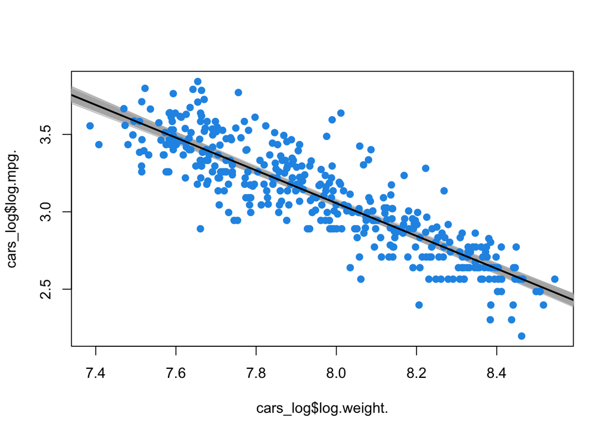

```r
plot(cars_log$log.weight.,cars_log$log.mpg.,col = NA,pch = 19)
boot_regr <- function(model, dataset){
  boot_index <- sample(1:nrow(dataset), replace= TRUE)
  data_boot <- dataset[boot_index,]
  regr_boot <- lm(model, data = data_boot)
  abline(regr_boot, lwd =1, col = rgb(0.7,0.7,0.7,0.5))
  regr_boot$coefficients
}
coeffs <- replicate(300,boot_regr(log.mpg.~log.weight.,cars_log))
points(cars_log$log.weight.,cars_log$log.mpg.,col = 4, pch = 19)
abline(a = mean(coeffs["(Intercept)",]), b = mean(coeffs["log.weight.",]),lwd = 2)
```

#### ii. Verify results with confidence interval using traditional methods

```r
quantile(coeffs["log.weight.",],c(0.025,0.975))
```

```
##      2.5%     97.5%
## -1.107420 -1.007253
```

Confidence Interval Plot

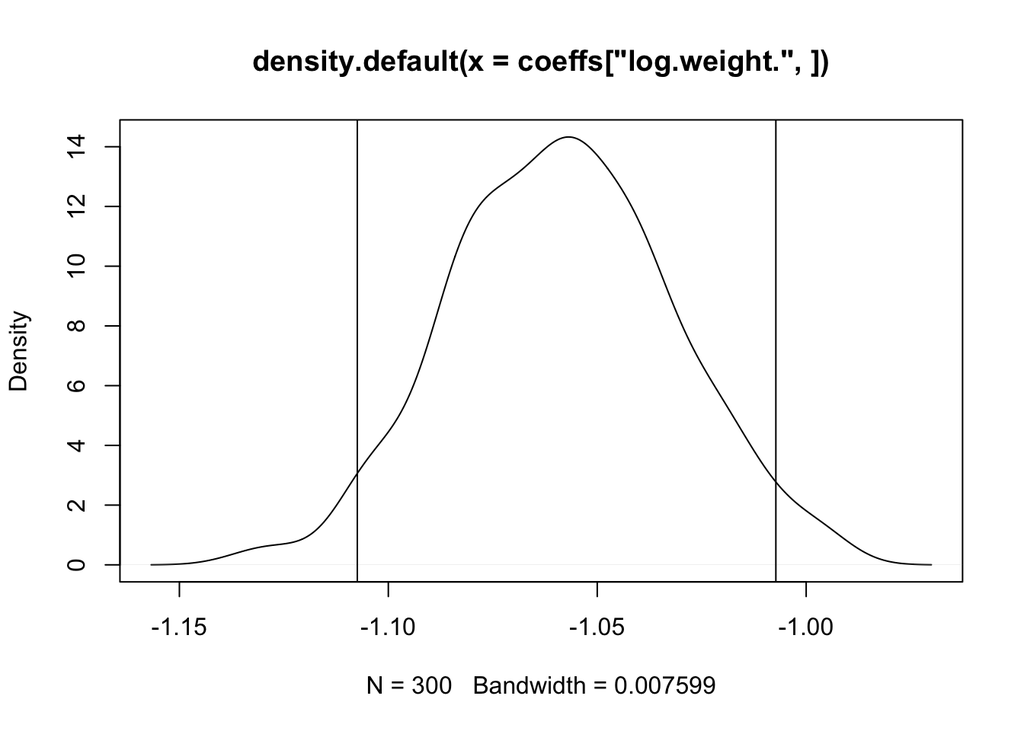

```r
plot(density(coeffs["log.weight.",]))
abline(v =quantile(coeffs["log.weight.",],c(0.025,0.975)))
```

Parametric Confidence Intervals

```r
hp_regr_log <- lm(log.mpg.~log.weight.,cars_log)
confint(hp_regr_log)
```

```
##                 2.5 %    97.5 %
## (Intercept) 11.060154 11.983659
## log.weight. -1.116264 -1.000272
```

## Question 2. Tackle multicollinearity

```r
regr_log <- lm(log.mpg. ~ log.cylinders. + log.displacement. + log.horsepower. +
                              log.weight. + log.acceleration. + model_year +
                              factor(origin),  data=cars_log)
```

### a. Use regression and R2 and calculate the VIF of log.weight.

```r
log_weight <- lm(log.weight. ~ log.cylinders. + log.displacement. + log.horsepower. + log.acceleration. + model_year + factor(origin),  data=cars_log)
r2_weight <- summary(log_weight)$r.squared
vif_weight <- 1/(1-r2_weight)
paste("weight r2 :",r2_weight, "weight vif:",vif_weight)
```

```
## [1] "weight r2 : 0.943101375320313 weight vif: 17.57511724808"
```

### b. Try Stepwise VIF selection to remove highly collinear variables

#### i. Compute VIF of all independent variables

```r
library(car)
vif_df <- vif(regr_log)
vif_df
```

```
##                        GVIF Df GVIF^(1/(2*Df))
## log.cylinders.    10.456738  1        3.233688
## log.displacement. 29.625732  1        5.442952
## log.horsepower.   12.132057  1        3.483110
## log.weight.       17.575117  1        4.192269
## log.acceleration.  3.570357  1        1.889539
## model_year         1.303738  1        1.141814
## factor(origin)     2.656795  2        1.276702
```

#### ii. Remove independent variable with largest VIF score greater than 5

```r
#Eliminate Displacement
regr_log1 <- lm(log.mpg. ~ log.cylinders. + log.horsepower. +
                              log.weight. + log.acceleration. + model_year +
                              factor(origin),  data=cars_log)
vif(regr_log1)
```

```
##                        GVIF Df GVIF^(1/(2*Df))
## log.cylinders.     5.433107  1        2.330903
## log.horsepower.   12.114475  1        3.480585
## log.weight.       11.239741  1        3.352572
## log.acceleration.  3.327967  1        1.824272
## model_year         1.291741  1        1.136548
## factor(origin)     1.897608  2        1.173685
```

#### iii. Repeat i, ii.

```r
#Eliminate horsepower
regr_log2 <- lm(log.mpg. ~ log.cylinders. +
                              log.weight. + log.acceleration. + model_year +
                              factor(origin),  data=cars_log)
vif(regr_log2)
```

```
##                       GVIF Df GVIF^(1/(2*Df))
## log.cylinders.    5.321090  1        2.306749
## log.weight.       4.788498  1        2.188264
## log.acceleration. 1.400111  1        1.183263
## model_year        1.201815  1        1.096273
## factor(origin)    1.792784  2        1.157130
```

```r
##Eliminate cylinders
regr_log3 <- lm(log.mpg. ~    log.weight. + log.acceleration. + model_year +
                              factor(origin),  data=cars_log)
vif(regr_log3)
```

```
##                       GVIF Df GVIF^(1/(2*Df))
## log.weight.       1.926377  1        1.387940
## log.acceleration. 1.303005  1        1.141493
## model_year        1.167241  1        1.080389
## factor(origin)    1.692320  2        1.140567
```

Now only *weight*,*acceleration*,*model_year*, *origin* remains

#### iv. Report final regression model

```r
regr_log3 <- lm(log.mpg. ~    log.weight. + log.acceleration. + model_year +
                              factor(origin),  data=cars_log)
summary(regr_log3)
```

```
##
## Call:
## lm(formula = log.mpg. ~ log.weight. + log.acceleration. + model_year +
##     factor(origin), data = cars_log)
##
## Residuals:
##      Min       1Q   Median       3Q      Max
## -0.38275 -0.07032  0.00491  0.06470  0.39913
##
## Coefficients:
##                    Estimate Std. Error t value Pr(>|t|)
## (Intercept)        7.431155   0.312248  23.799  < 2e-16 ***
## log.weight.       -0.876608   0.028697 -30.547  < 2e-16 ***
## log.acceleration.  0.051508   0.036652   1.405  0.16072
## model_year         0.032734   0.001696  19.306  < 2e-16 ***
## factor(origin)2    0.057991   0.017885   3.242  0.00129 **
## factor(origin)3    0.032333   0.018279   1.769  0.07770 .
## ---
## Signif. codes:  0 '***' 0.001 '**' 0.01 '*' 0.05 '.' 0.1 ' ' 1
##
## Residual standard error: 0.1156 on 392 degrees of freedom
## Multiple R-squared:  0.8856, Adjusted R-squared:  0.8841
## F-statistic: 606.8 on 5 and 392 DF,  p-value: < 2.2e-16
```

### d. General quesionts of VIF

#### i. If an independent variable has no correlation with other independent variables, what would its VIF be?

**ANSWER:** VIF is calculated using the R squared values. If there is no correlation within the variables, then the R sqaured values would be 0 and so it’s VIF will be 1.

#### ii. Regression with 2 independent variables(X1,X2), how correlated would X1, X2 be to get VIF higher than 5, 10?

$$VIF = 1/(1-r^2)\\
r = 0.894(VIF=5)\\
r= 0.949(VIF=10)$$

## Question 3

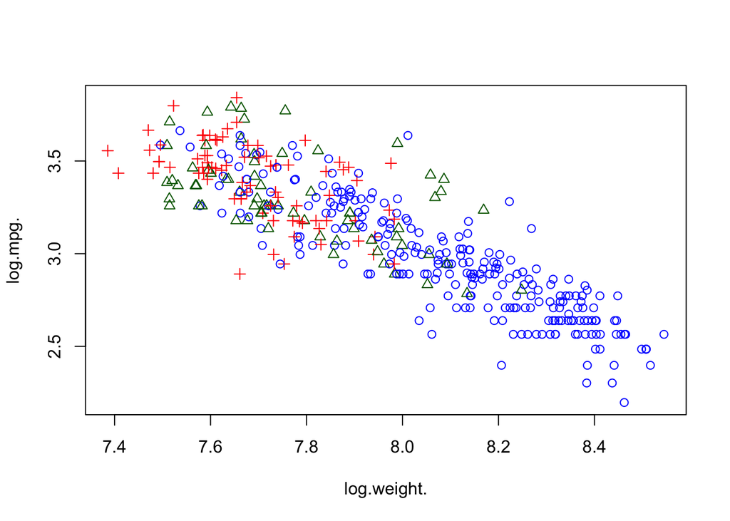

```r
origin_colors = c("blue", "darkgreen", "red")
with(cars_log, plot(log.weight., log.mpg., pch=origin, col=origin_colors[origin]))
```

### a.

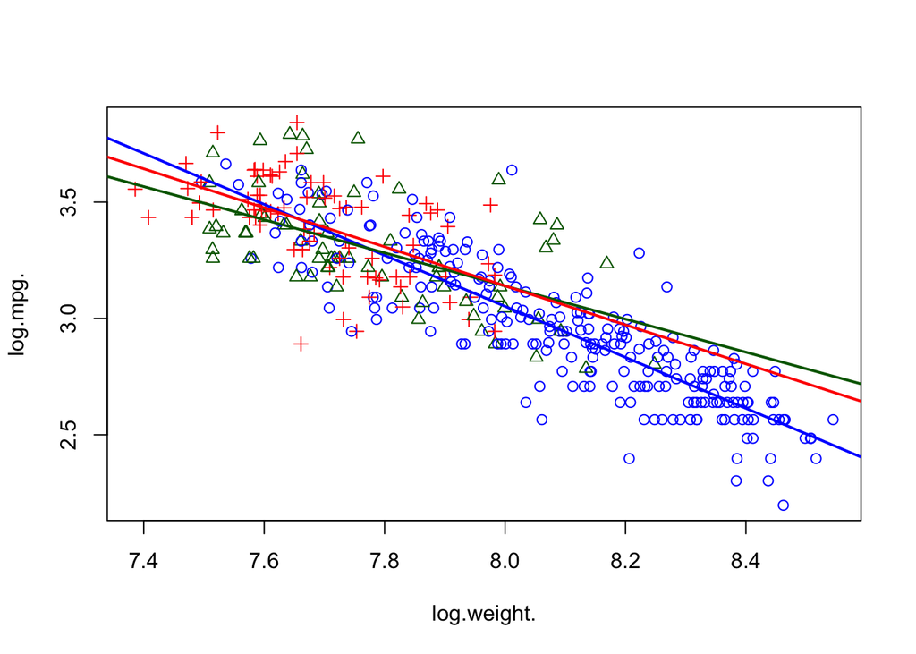

```r
with(cars_log, plot(log.weight., log.mpg., pch=origin, col=origin_colors[origin]))
cars_us <- subset(cars_log, origin==1)
cars_eu <- subset(cars_log, origin==2)
cars_jp <- subset(cars_log, origin==3)
wt_regr_us <- lm(log.mpg. ~ log.weight., data=cars_us)
wt_regr_eu <- lm(log.mpg. ~ log.weight., data=cars_eu)
wt_regr_jp <- lm(log.mpg. ~ log.weight., data=cars_jp)
abline(wt_regr_us, col=origin_colors[1], lwd=2)
abline(wt_regr_eu, col=origin_colors[2], lwd=2)
abline(wt_regr_jp, col=origin_colors[3], lwd=2)
```